# Data Visualization Assignment #1

Anna Takacs

2/17/2020

# Indebted to Learn

The following study aims at describing the financial state of households in the United States from 1989 onward with a focus on education loans. It builds upon the Survey of Consumer Finances that is available until 2016.

# 1. Debt over time

This part of the analysis focuses on how household indebtedness has evolved over time.

### 1.1

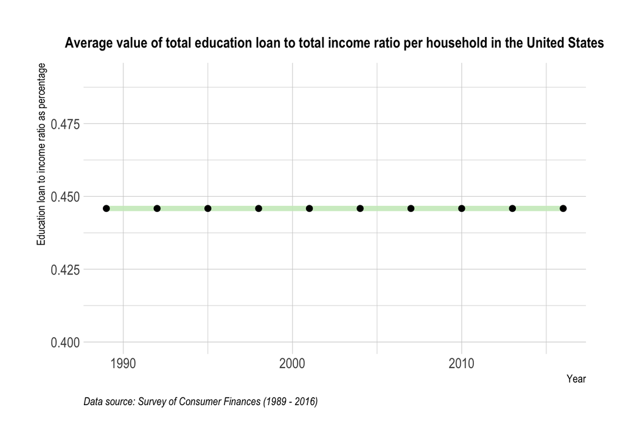

### 1.2

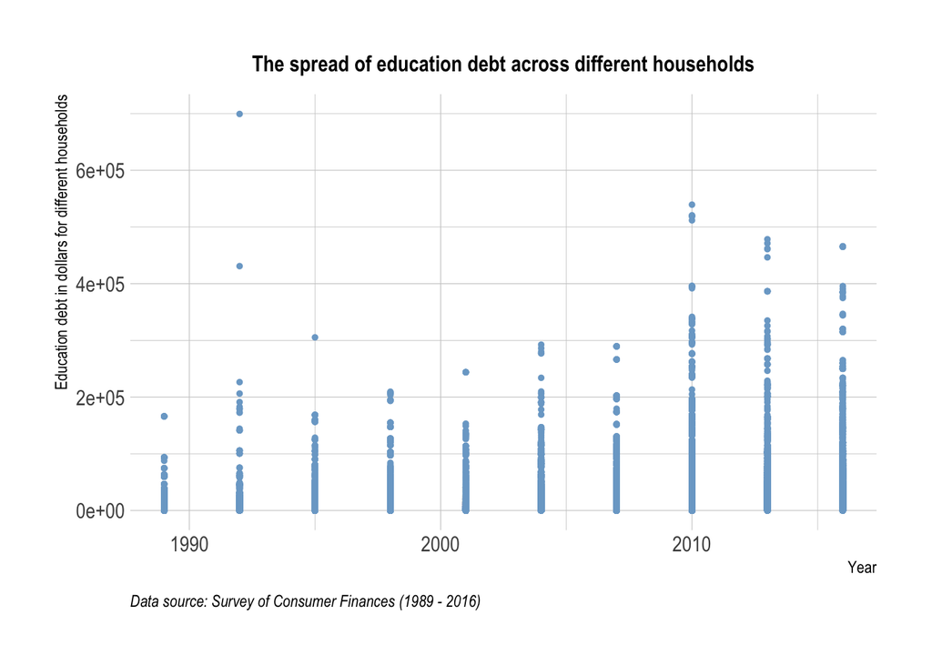

### 1.3

**How did student loan debt compare to other types of debt (car loans, mortgage, credit card, etc.)?**

The stacked bar chart below allows us to follow the overall value of debts over time and break down the analysis to its components.

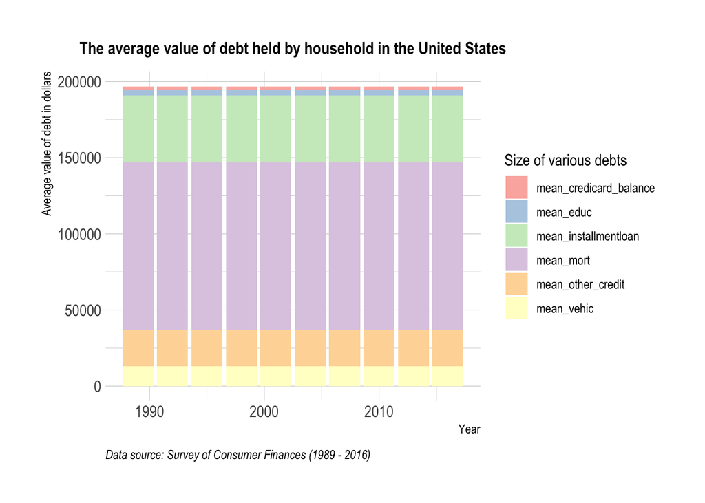

# 2. Tell me who you are

This part of the analysis looks at the data only for 2016 and would like to uncover patterns ralated to family background.

In the following sections the variable for education loan is regrouped into the following categories:

- 0: Zero
- 1 - 50 000: Low
- 50 001 - 200 000: Moderate
- 200 001 - 300 000: Average
- 300 001 - 400 000: Growing
- 400 001 and above: High

### 2.3

The below graph observes differences between households where the head of the household has obtained a minimum of one degree and where they haven’t. The type of the bar chart is designed to show proportions compared to the total number of people in each groups.

It is visible that in the degree holder group the households tend to take on a larger proportion of education loan on average compared to the non-degree holder group where more people fall into the category holding only a low value of education loan.

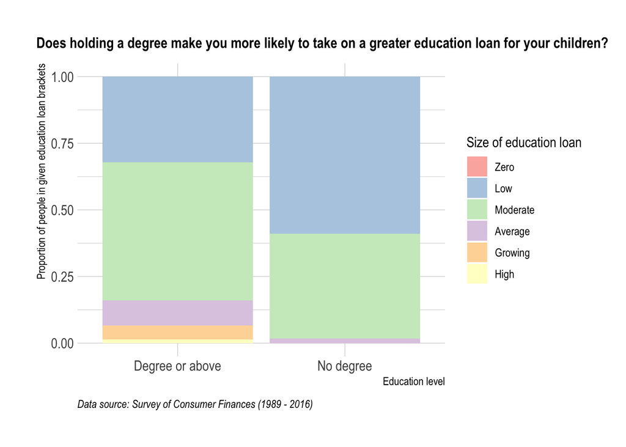

### 2.2

The next up graph aim to observe the age range of the head of the household holding different amount of education loans. This type of boxplot, especially in the arangement that age is on the x-axis, allows the reader to see age as a continuous variable and show “how long being heavily indebted with education loan lasts”.

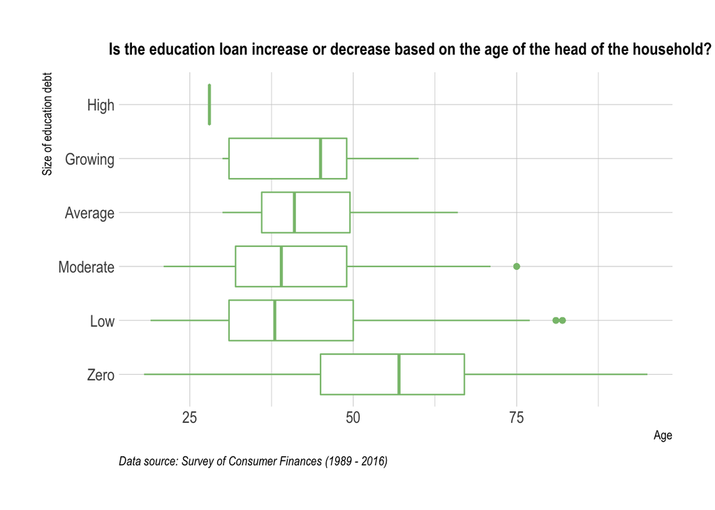

### 2.3

Graph 2.3 aims to observe deviations in education loans for different type of households. As before, the boxplot was not an effective way to visualize trends as even with restricting the y axis, the values were too skewed. This faceting for scatterplots works well for comparing hosueholds as the values can be directly put next to each other and labels can show clear differences between different facets.

As the graph does not provide information about mean values, we can only draw conclusion about the spread of education loans held by the households. Even though differences are not large, it is important to note that we can only see higher values of edcuation debt in the *Black/African American* category, while other categories show larger values for men. on the other hand, in the *White, non-hispanic* category, the value of education debt is more evenly spread out for both men and women, raising the question whether conclusion can be drawn that those households where the head is white or non-hispanic tend to take on education debts more consistenly across time and space.

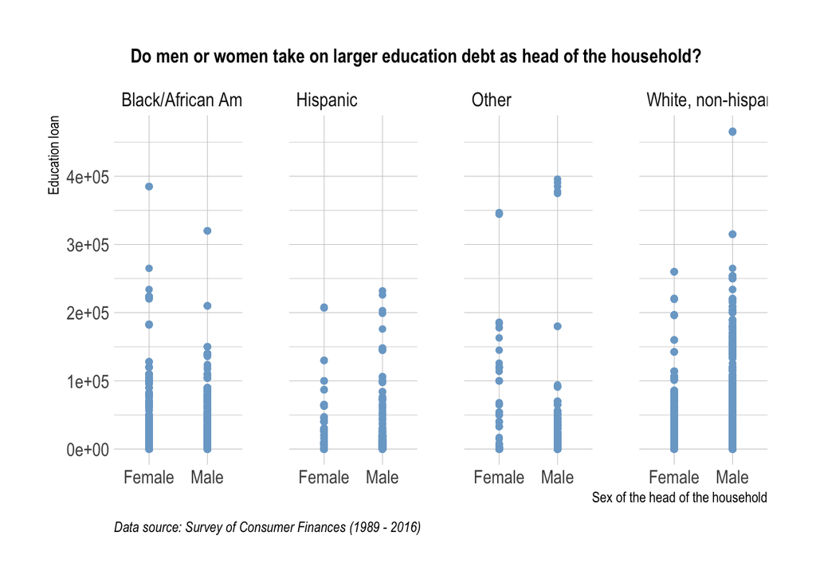

# 3. Wealth and Income Distribution

This section aims at observing trends between education loan and income and wealth for the year of 2016.

### 3.1

There is a triangle between age, wealth and loans that households take on. It is a trade-off for families but the dynamics behind the decision is not clear. For this reason, the following graph aims to visualize the trend between these three variables. The smoothened line is added to articulate the relationship between education loan and age better in case it would be clear from the scatter.

As before, we can see that the size of the education loan decreases as the head of the household gets older and eventually gets closer to zero. However, when looking at vertical differences in the graph and making comparison between families holding large and smaller education loans and their income percentile groups: we are not able to observe a clear trend. It is both the case that weathier families hold small and large amount of education loan and that lower income households do the same.

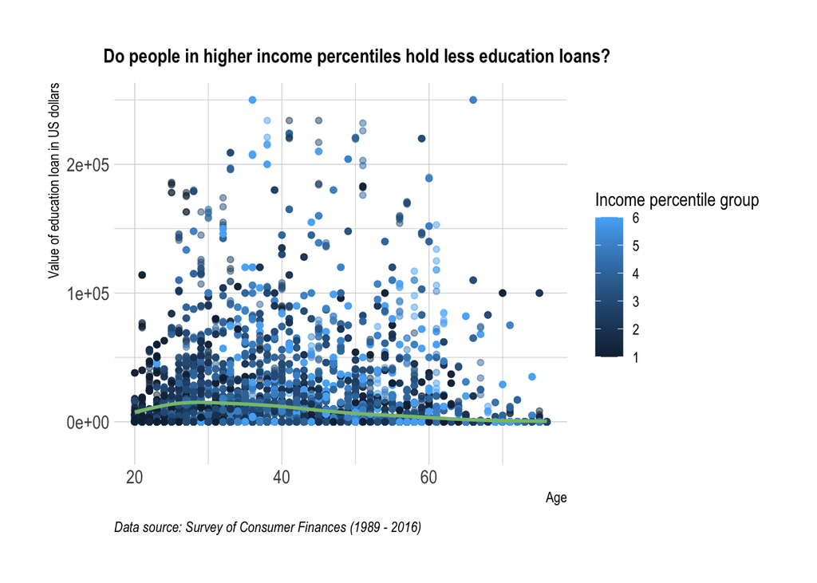

### 3.2

As before, I use facets to shows clear trends between groups. Here the facets compare groups with different amount of education loans.

Interesting to note in the separate facets the skewdness of dots differs between loan categories. In the first facet from the left, the net value percentile group tends to be higher than the income percentile group, while in the second and third facet this relationship changes in a suble way. This implies that those families who take on larger education loans on average rank higher in terms of income percentile group than according to the net value percentile group.

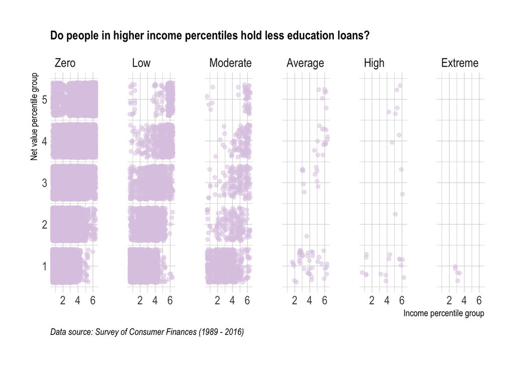

# 4. Going broke

Part 4 of this analysis focuses again on the whole dataset available from 1989 to 2016.

### 4.1

As the below graph shows trends over time for average value of income, average value of debt and education loan for two different household types: ones who declared bankruptcy and the ones who did not.

Education loan did not seem to play a significant role in the bankrupcy of the households.

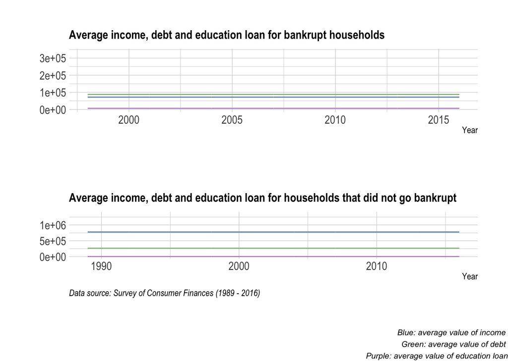

### 4.2

The last graph in this section aims to see whether households holding different value of debt (all debt included) show distinct trends in their food deliveries.

As it is visible, those families in the most indebted category spend the most annually on food delivery on average and those households in “in-between” categories spend less than households without any debt. As a conclusion, it is a U-shaped relationship: as people start to take on debts they reduce their delivery spendings but after a certain amount of debt they reverse that trend.

This line graph monitors overtime trends and as lines depict different groups in our sample, the comparison becomes easier.

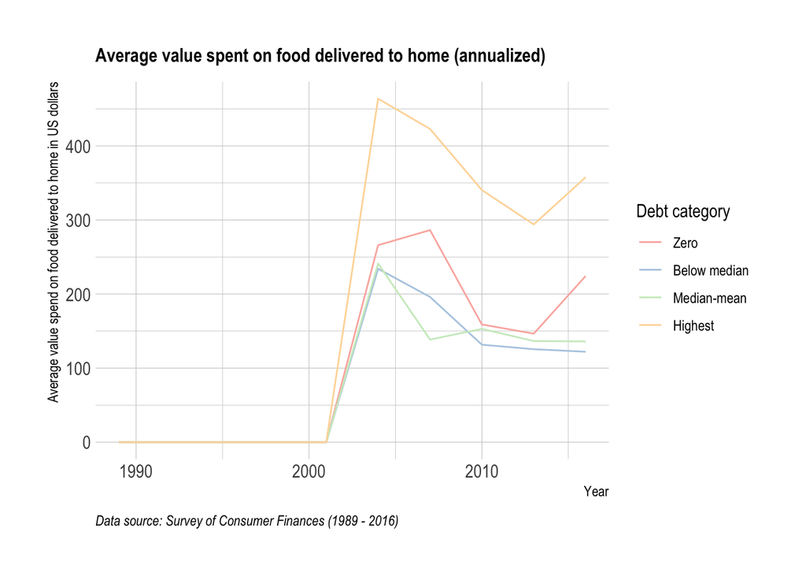

# Interactivity

Transforming graphs from static to interactive format is only important when the interactive format will offer more insights into the original graph.

### 4.1

As in stacked bar charts the values are not clear for each stack, I wanted to create an interective version so that more concrete information is available for each debt category for each year.

[interactive chart not shown]

### 4.2

Lastly, I chose a “clickbait” graph as the lines on this graph cross numerous times and I thought that it would be insightful to see the concrete values at given point in time.

[interactive chart not shown]

# 6. Data Table

### 6.1

The below data table allows the reader to search observations of households who went bankrupt and who didn’t and look at the range of indebtedness those had, the range of education loans they held and years when they indicated their bankruptcy (within 5 years of time). The reader can furthermore search for the amount of education loan and see whether for example those households who did not take on any loan belonged to a higher earning group.

|  | Year | Income | Debt In Dollars | Education Loan | Bankrupt? |
| --- | --- | --- | --- | --- | --- |
| 1 | 1989 | 9737166.85 | 0 | 0 | No |
| 2 | 1989 | 9737166.85 | 0 | 0 | No |
| 3 | 1989 | 9737166.85 | 0 | 0 | No |
| 4 | 1989 | 9737166.85 | 0 | 0 | No |
| 5 | 1989 | 9737166.85 | 0 | 0 | No |
| 6 | 1989 | 19279590.36 | 5737519.73 | 0 | No |
| 7 | 1989 | 13711878.36 | 5737519.73 | 0 | No |
| 8 | 1989 | 16118906 | 5737519.73 | 0 | No |
| 9 | 1989 | 15125714.98 | 5737519.73 | 0 | No |
| 10 | 1989 | 18660306.55 | 5737519.73 | 0 | No |

[output cut: 6701 more lines]